# R Notebook

## Declaring packages

```r
library(TSA)
library(tseries)
library(tidyverse)
```

## Checking the parameters of the ARIMA model for USDPHP

### First we load the data set

```r
data <- read_csv("https://raw.githubusercontent.com/leesalasa/Math_Research/main/data/Dollar-Peso.csv")
head(data)
```

| Month | spot | ln(spot) | GDP | ln(GDP) | CPI | ln(CPI) | M3 | ln(M3) | BoT | diff(rate) |
| --- | --- | --- | --- | --- | --- | --- | --- | --- | --- | --- |
| Jan-99 | 38.717 | 3.656279 | 358.8934 | 5.883025 | 1.267150 | 0.2367700 | 199.0203 | 5.293407 | -123.62951 | -8.349 |
| Feb-99 | 39.098 | 3.666071 | 369.7338 | 5.912783 | 1.258112 | 0.2296122 | 200.9744 | 5.303177 | -80.40762 | -7.831 |
| Mar-99 | 38.766 | 3.657544 | 377.4649 | 5.933478 | 1.255183 | 0.2272816 | 199.5607 | 5.296118 | -530.92628 | -7.226 |
| Apr-99 | 38.018 | 3.638060 | 386.2397 | 5.956458 | 1.255717 | 0.2277067 | 201.2292 | 5.304444 | 96.92310 | -5.970 |
| May-99 | 38.095 | 3.640083 | 396.1050 | 5.981679 | 1.257332 | 0.2289917 | 197.7207 | 5.286855 | -125.07634 | -5.040 |
| Jun-99 | 38.019 | 3.638086 | 402.7597 | 5.998340 | 1.248736 | 0.2221315 | 195.5234 | 5.275680 | -159.73562 | -4.128 |

```r
spot <- ts(data$'ln(spot)', start = c(1999,1,1), end = c(2018,12,31), frequency = 12)
```

### We then check for stationarity

```r
adf.test(spot)
```

```
    Augmented Dickey-Fuller Test

data:  spot
Dickey-Fuller = -2.6413, Lag order = 6, p-value = 0.3062
alternative hypothesis: stationary
```

We get a p-value of 0.3062 which means that the series is non-stationary and so We difference the series then check stationarity again.

```r
spot.dif <- diff(spot)
adf.test(spot.dif)
```

```
    Augmented Dickey-Fuller Test

data:  spot.dif
Dickey-Fuller = -5.0142, Lag order = 6, p-value = 0.01
alternative hypothesis: stationary
```

From the ADF test, the series is now stationary.

### We then check the ACF and PACF graphs of the series

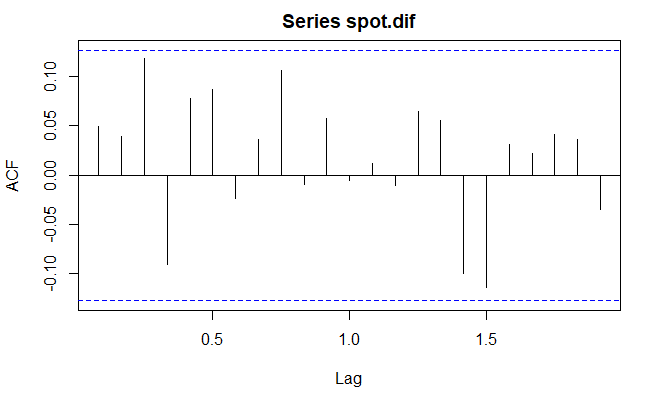

```r
acf(spot.dif)
```

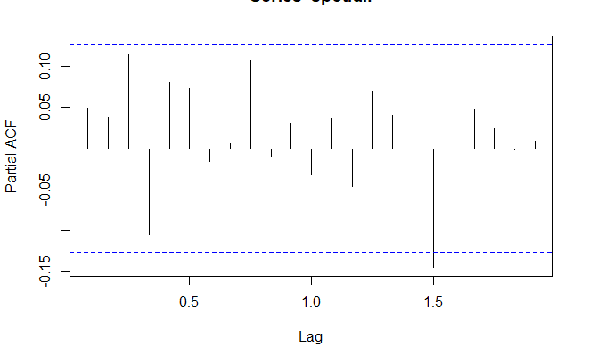

```r
pacf(spot.dif)
```

From the acf and pacf it looks like the data has the parameters (0,1,0) since it doesn’t have a significant lag spike followed by a decay in both graphs. We then check its EACF table to confirm this.

```r
eacf(spot.dif)
```

```
AR/MA
  0 1 2 3 4 5 6 7 8 9 10 11 12 13
0 o o o o o o o o o o o  o  o  o
1 x o o o o o o o o o o  o  o  o
2 x x o o o o o o o o o  o  o  o
3 x o x o o o o o o o o  o  o  o
4 x o x x o o o o o o o  o  o  o
5 x x x x x o o o o o o  o  o  o
6 x o x x o o o o o o o  o  o  o
7 x o x x o o o o o o o  o  o  o
```

From the EACF table it is clear that the series has parameters (0,1,0) which is equivalent to a random walk.

## Checking the parameters of the ARIMA model for EURPHP

### First we load the data set

```r
data2 <- read_csv("https://raw.githubusercontent.com/leesalasa/Math_Research/main/data/Euro-Peso.csv")
head(data2)
```

| Month | spot | ln(spot) | GDP | ln(GDP) | CPI | ln(CPI) | M3 | ln(M3) | BoT | diff(rate) |
| --- | --- | --- | --- | --- | --- | --- | --- | --- | --- | --- |
| Jan-99 | 44.2380 | 3.789584 | 73.36619 | 4.295463 | 1.331525 | 0.2863249 | 227.9193 | 5.428992 | -16.559244 | -10.11 |
| Feb-99 | 43.1603 | 3.764921 | 72.15965 | 4.278881 | 1.327956 | 0.2836410 | 228.1562 | 5.430030 | 6.762509 | -9.64 |
| Mar-99 | 41.5843 | 3.727723 | 71.43736 | 4.268821 | 1.328526 | 0.2840700 | 226.8140 | 5.424130 | 65.812147 | -9.09 |
| Apr-99 | 40.3523 | 3.697648 | 71.38307 | 4.268061 | 1.331119 | 0.2860200 | 229.1008 | 5.434162 | -9.219787 | -8.15 |
| May-99 | 39.7369 | 3.682280 | 72.16677 | 4.278980 | 1.332744 | 0.2872400 | 225.5299 | 5.418453 | -4.625224 | -7.38 |
| Jun-99 | 39.2812 | 3.670746 | 72.80832 | 4.287830 | 1.321968 | 0.2791217 | 223.2434 | 5.408263 | 33.683458 | -6.63 |

```r
spot2 <- ts(data2$'ln(spot)', start = c(1999,1,1), end = c(2018,12,31), frequency = 12)
```

### We then check for stationarity

```r
adf.test(spot2)
```

```
    Augmented Dickey-Fuller Test

data:  spot2
Dickey-Fuller = -2.0906, Lag order = 6, p-value = 0.5377
alternative hypothesis: stationary
```

We get a p-value of 0.5377 which means that the series is non-stationary and so We difference the series then check stationarity again.

```r
spot2.dif <- diff(spot2)
adf.test(spot2.dif)
```

```
    Augmented Dickey-Fuller Test

data:  spot2.dif
Dickey-Fuller = -5.8698, Lag order = 6, p-value = 0.01
alternative hypothesis: stationary
```

From the ADF test, the series is now stationary.

### We then check the ACF and PACF graphs of the series

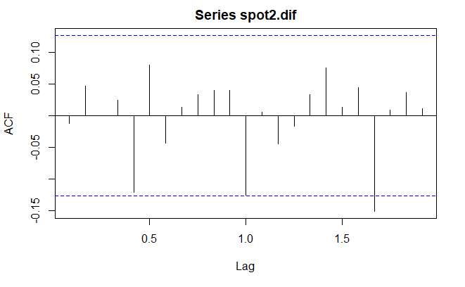

```r
acf(spot2.dif)
```

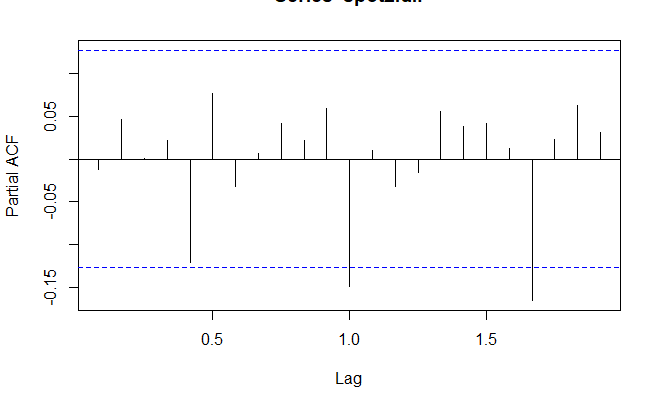

```r
pacf(spot2.dif)
```

```r
eacf(spot2.dif)
```

```
AR/MA
  0 1 2 3 4 5 6 7 8 9 10 11 12 13
0 o o o o o o o o o o o  o  o  o
1 x o o o o o o o o o o  o  o  o
2 o x o o o o o o o o o  o  o  o
3 o o x o o o o o o o o  x  o  o
4 x o x o o o o o o o o  o  o  o
5 x o o x x o o o o o o  o  o  o
6 x o o o o x o o o o o  o  o  o
7 x o x x o x x o o o o  o  o  o
```

From the EACF table it is clear that the series has parameters (0,1,0) which is equivalent to a random walk.

## Checking the parameters of the ARIMA model for YENPHP

### First we load the data set

```r
data3 <- read_csv("https://raw.githubusercontent.com/leesalasa/Math_Research/main/data/Yen-Peso.csv")
head(data3)
```

| Month | spot | ln(spot) | GDP | ln(GDP) | CPI | ln(CPI) | M3 | ln(M3) | BoT | diff(rate) |
| --- | --- | --- | --- | --- | --- | --- | --- | --- | --- | --- |
| Jan-99 | 0.3329 | -1.099913 | 130.6518 | 4.872536 | 1.806017 | 0.5911239 | 367.0926 | 5.905614 | 36.25375 | -12.739 |
| Feb-99 | 0.3268 | -1.118407 | 128.4317 | 4.855397 | 1.788948 | 0.5816278 | 369.6615 | 5.912588 | 25.90085 | -12.231 |
| Mar-99 | 0.3223 | -1.132272 | 127.0714 | 4.844749 | 1.787564 | 0.5808539 | 368.0207 | 5.908139 | 246.38274 | -11.636 |
| Apr-99 | 0.3195 | -1.140998 | 126.8680 | 4.843147 | 1.796703 | 0.5859533 | 369.1485 | 5.911199 | -35.62154 | -10.350 |
| May-99 | 0.3133 | -1.160594 | 128.1132 | 4.852914 | 1.796703 | 0.5859533 | 362.0224 | 5.891706 | 33.43021 | -9.460 |
| Jun-99 | 0.3142 | -1.157726 | 129.0007 | 4.859818 | 1.775284 | 0.5739601 | 357.6139 | 5.879454 | 54.29307 | -8.758 |

```r
spot3 <- ts(data3$'ln(spot)', start = c(1999,1,1), end = c(2018,12,31), frequency = 12)
```

### We then check for stationarity

```r
adf.test(spot3)
```

```
    Augmented Dickey-Fuller Test

data:  spot3
Dickey-Fuller = -2.6986, Lag order = 6, p-value = 0.2821
alternative hypothesis: stationary
```

We get a p-value of 0.2821 which means that the series is non-stationary and so We difference the series then check stationarity again.

```r
spot3.dif <- diff(spot3)
adf.test(spot3.dif)
```

```
    Augmented Dickey-Fuller Test

data:  spot3.dif
Dickey-Fuller = -5.5717, Lag order = 6, p-value = 0.01
alternative hypothesis: stationary
```

From the ADF test, the series is now stationary.

### We then check the ACF and PACF graphs of the series

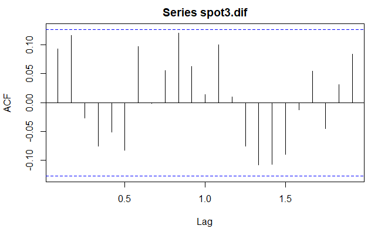

```r
acf(spot3.dif)
```

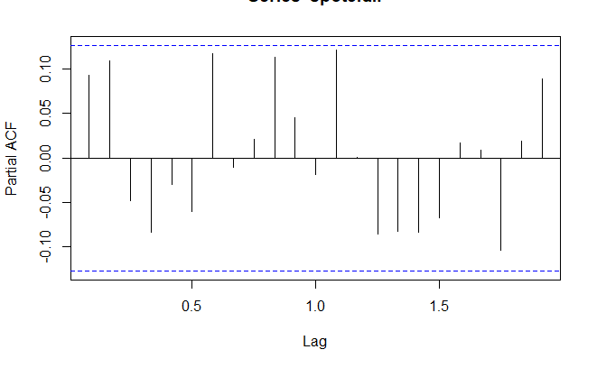

```r
pacf(spot3.dif)
```

From the acf and pacf it looks like the data has the parameters (0,1,0) since it doesn’t have a significant lag spike followed by a decay in both graphs. We then check its EACF table to confirm this.

```r
eacf(spot3.dif)
```

```
AR/MA
  0 1 2 3 4 5 6 7 8 9 10 11 12 13
0 o o o o o o o o o o o  o  o  o
1 x o o o o o o o o o o  o  o  o
2 x x o o o o o o o o o  o  o  o
3 x x x o o o o o o o o  o  o  o
4 x x o x o o o o o o o  o  o  o
5 x x x x o o o o o o o  o  o  o
6 x x x x o o o o o o o  o  o  o
7 o x x o x o o o o o o  o  o  o
```

From the EACF table it is clear that the series has parameters (0,1,0) which is equivalent to a random walk.